# Project Foundations for Data Science: FoodHub Data Analysis

**Marks: 40**

### Context

The number of restaurants in New York is increasing day by day. Lots of students and busy professionals rely on those restaurants due to their hectic lifestyles. Online food delivery service is a great option for them. It provides them with good food from their favorite restaurants. A food aggregator company FoodHub offers access to multiple restaurants through a single smartphone app.

The app allows the restaurants to receive a direct online order from a customer. The app assigns a delivery person from the company to pick up the order after it is confirmed by the restaurant. The delivery person then uses the map to reach the restaurant and waits for the food package. Once the food package is handed over to the delivery person, he/she confirms the pick-up in the app and travels to the customer's location to deliver the food. The delivery person confirms the drop-off in the app after delivering the food package to the customer. The customer can rate the order in the app. The food aggregator earns money by collecting a fixed margin of the delivery order from the restaurants.

### Objective

The food aggregator company has stored the data of the different orders made by the registered customers in their online portal. They want to analyze the data to get a fair idea about the demand of different restaurants which will help them in enhancing their customer experience. Suppose you are hired as a Data Scientist in this company and the Data Science team has shared some of the key questions that need to be answered. Perform the data analysis to find answers to these questions that will help the company to improve the business.

### Data Description

The data contains the different data related to a food order. The detailed data dictionary is given below.

### Data Dictionary

- order_id: Unique ID of the order
- customer_id: ID of the customer who ordered the food
- restaurant_name: Name of the restaurant
- cuisine_type: Cuisine ordered by the customer
- cost: Cost of the order
- day_of_the_week: Indicates whether the order is placed on a weekday or weekend (The weekday is from Monday to Friday and the weekend is Saturday and Sunday)
- rating: Rating given by the customer out of 5
- food_preparation_time: Time (in minutes) taken by the restaurant to prepare the food. This is calculated by taking the difference between the timestamps of the restaurant's order confirmation and the delivery person's pick-up confirmation.
- delivery_time: Time (in minutes) taken by the delivery person to deliver the food package. This is calculated by taking the difference between the timestamps of the delivery person's pick-up confirmation and drop-off information

### Let us start by importing the required libraries

```python
import numpy as np
import pandas as pd
import matplotlib.pyplot as plt
import seaborn as sns
```

### Understanding the structure of the data

```python
from google.colab import drive
drive.mount('/content/drive')
```

```python
df = pd.read_csv('/content/drive/MyDrive/Python course/foodhub_order.csv')
df.head()
```

|  | order_id | customer_id | restaurant_name | cuisine_type | cost_of_the_order | day_of_the_week | rating | food_preparation_time | delivery_time |
| --- | --- | --- | --- | --- | --- | --- | --- | --- | --- |
| 0 | 1477147 | 337525 | Hangawi | Korean | 30.75 | Weekend | Not given | 25 | 20 |
| 1 | 1477685 | 358141 | Blue Ribbon Sushi Izakaya | Japanese | 12.08 | Weekend | Not given | 25 | 23 |
| 2 | 1477070 | 66393 | Cafe Habana | Mexican | 12.23 | Weekday | 5 | 23 | 28 |
| 3 | 1477334 | 106968 | Blue Ribbon Fried Chicken | American | 29.20 | Weekend | 3 | 25 | 15 |
| 4 | 1478249 | 76942 | Dirty Bird to Go | American | 11.59 | Weekday | 4 | 25 | 24 |

#### Observations:

The DataFrame has 9 columns as mentioned in the Data Dictionary. Data in each row corresponds to the order placed by a customer.

```
# This is formatted as code
```

### **Question 1:** How many rows and columns are present in the data?

```python
rows, columns = df.shape
print(f'The data has {rows} rows and {columns} columns.')
```

```
The data has 1898 rows and 9 columns.
```

### **Question 2:** What are the datatypes of the different columns in the dataset? (The info() function can be used)

```python
df.info()
```

```
<class 'pandas.core.frame.DataFrame'>
RangeIndex: 1898 entries, 0 to 1897
Data columns (total 9 columns):
 #   Column                 Non-Null Count  Dtype
---  ------                 --------------  -----
 0   order_id               1898 non-null   int64
 1   customer_id            1898 non-null   int64
 2   restaurant_name        1898 non-null   object
 3   cuisine_type           1898 non-null   object
 4   cost_of_the_order      1898 non-null   float64
 5   day_of_the_week        1898 non-null   object
 6   rating                 1898 non-null   object
 7   food_preparation_time  1898 non-null   int64
 8   delivery_time          1898 non-null   int64
dtypes: float64(1), int64(4), object(4)
memory usage: 133.6+ KB
```

#### Observations:

- The dataset contains 1898 complete entries with no missing values.
- Numerical columns (order_id, customer_id, cost_of_the_order, food_preparation_time, delivery_time) are correctly typed.
- Categorical columns (restaurant_name, cuisine_type, day_of_the_week, rating) are appropriately identified as objects.
- The rating column includes both numerical ratings and 'Not given' entries, which need handling for accurate analysis.

### **Question 3:** Are there any missing values in the data? If yes, treat them using an appropriate method

```python
# Check missing values in the DataFrame
missing_values = df.isnull().sum()
print("Missing values in each column:\n", missing_values)
```

```
Missing values in each column:
 order_id                 0
customer_id              0
restaurant_name          0
cuisine_type             0
cost_of_the_order        0
day_of_the_week          0
rating                   0
food_preparation_time    0
delivery_time            0
dtype: int64
```

#### Observations: There are no missing values in the dataset. However, there are 'Not given' values under the rating column, which should be treated as missing values. These should be eliminated if we need to use the ratings for any calculations

### **Question 4:** Check the statistical summary of the data. What is the minimum, average, and maximum time it takes for food to be prepared once an order is placed?

```python
df.describe(include='all').T
```

[output not shown]

```python
#Find the statistical summary of the 'food_preparation_time' column
food_preparation_summary = df['food_preparation_time'].describe()

# Extract the minimum, average, and maximum values
min_time = food_preparation_summary['min']
average_time = food_preparation_summary['mean']
max_time = food_preparation_summary['max']

print(f'Minimum preparation time: {min_time} minutes')
print(f'Average preparation time: {average_time:.2f} minutes')
print(f'Maximum preparation time: {max_time} minutes')
```

```
Minimum preparation time: 20.0 minutes
Average preparation time: 27.37 minutes
Maximum preparation time: 35.0 minutes
```

### **Question 5:** How many orders are not rated?

```python
# Count the number of "Not given" entries in the 'rating' column
not_given_count = df[df['rating'] == 'Not given'].shape[0]

print(f'The number of "Not given" entries in the rating column: {not_given_count}')
```

```
The number of "Not given" entries in the rating column: 736
```

#### Observations:

- A significant number of orders do not have ratings, which should be accounted for in any analysis involving customer satisfaction.

### Exploratory Data Analysis (EDA)

### **Question 6:** Explore all the variables and provide observations on their distributions. (Generally, histograms, boxplots, countplots, etc. are used for univariate exploration)

# Histograms visualization for numerical columns

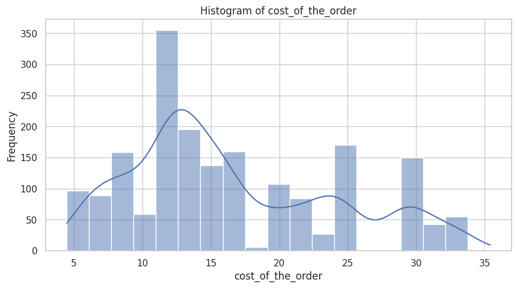

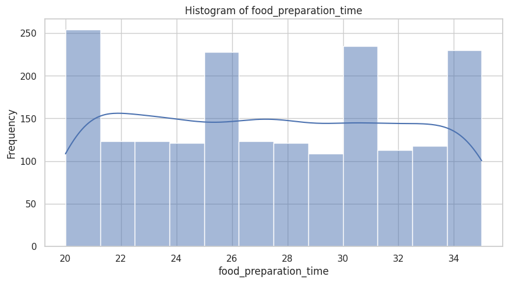

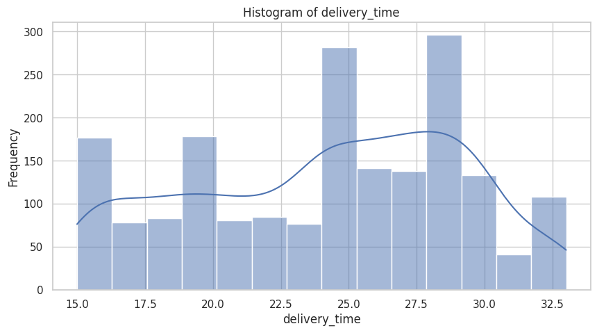

```python
# Set the style of the visualizations
sns.set(style="whitegrid")

# Plot histograms for numerical columns
numerical_columns = ['cost_of_the_order', 'food_preparation_time', 'delivery_time']
for column in numerical_columns:
    plt.figure(figsize=(10, 5))
    sns.histplot(df[column], kde=True)
    plt.title(f'Histogram of {column}')
    plt.xlabel(column)
    plt.ylabel('Frequency')
    plt.show()
```

#### Observations and Insights from Numerical Variables:

#### Histogram of Cost of the Order:

- Observation The cost of orders is mostly concentrated between $10 and $15, with a peak around $12.
- Insight: There is a higher frequency of mid-range cost orders, indicating that customers tend to place orders within this price range. Promotions and marketing strategies could focus on this popular price bracket to maximize sales.

#### Histogram of Food Preparation Time

- Observation Food preparation times are fairly evenly distributed, with noticeable peaks at 20, 26, 30, and 34 minutes.
- Insight: The even distribution suggests that preparation times vary significantly among different restaurants or cuisines. Identifying restaurants with longer preparation times could help improve overall efficiency by implementing targeted process improvements.

#### Histogram of Delivery Time:

- Observation: Delivery times are primarily concentrated around 25 to 30 minutes, with peaks at 25 and 28 minutes. Insight: The majority of deliveries are completed within this time frame, indicating that the delivery service is relatively consistent. However, there are noticeable delays at times exceeding 30 minutes, which might need attention to ensure customer satisfaction during peak hours or in certain areas.

# Boxplot

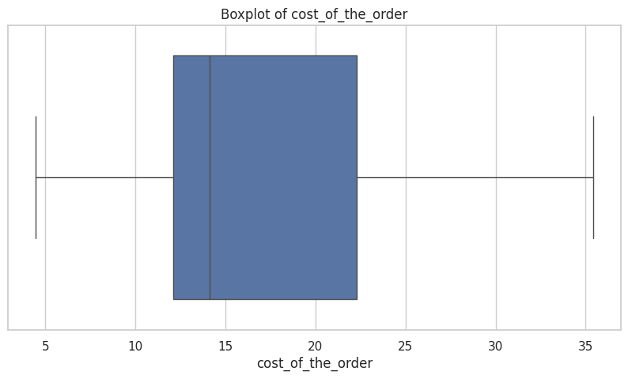

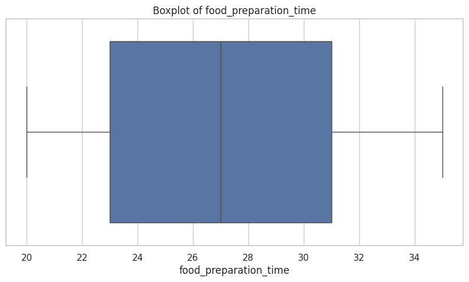

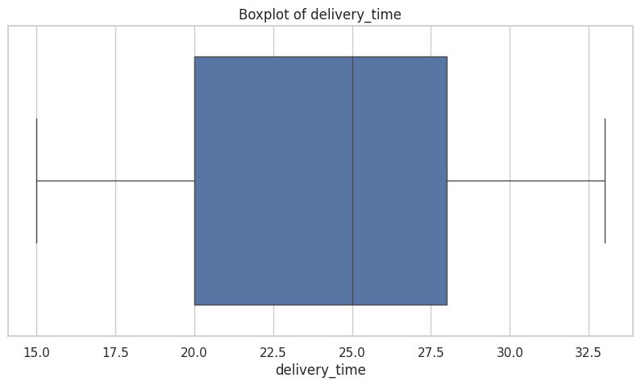

```python
# Plot boxplots for numerical columns
for column in numerical_columns:
    plt.figure(figsize=(10, 5))
    sns.boxplot(x=df[column])
    plt.title(f'Boxplot of {column}')
    plt.xlabel(column)
    plt.show()
```

#### Boxplot of Food Preparation Time:

- Observation: Food preparation times range from 20 to 35 minutes. The IQR is from 23 to 31 minutes, with a median preparation time of 27 minutes.
- Insight: The preparation times are fairly evenly distributed within the range, with no significant outliers. This suggests that most restaurants have a consistent preparation time, which is crucial for maintaining delivery schedules.

#### Boxplot of Delivery Time:

- Observation: Delivery times range from 15 to 32.5 minutes. The IQR is from 20 to 28 minutes, with a median delivery time of around 25 minutes.
- Insight: The delivery times show a consistent distribution with no extreme outliers. The median delivery time of 25 minutes aligns well with customer expectations for timely delivery. However, there is a slight spread towards longer delivery times, which might need optimization, especially during peak hours.

# Plot countplots for categorical columns

[figure not shown]

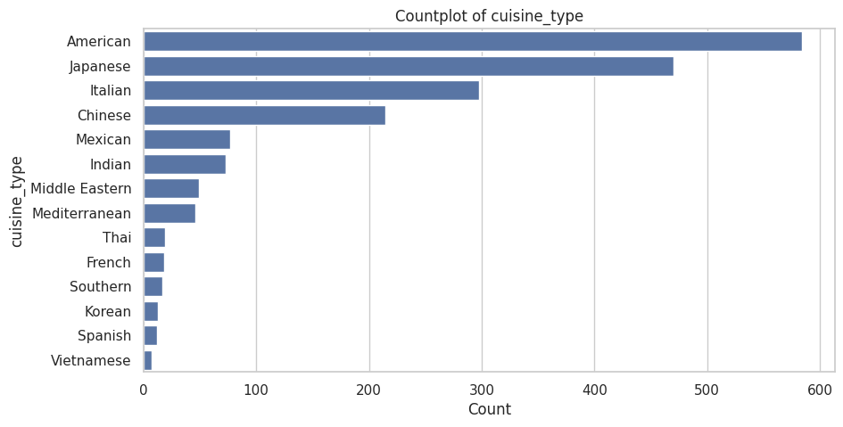

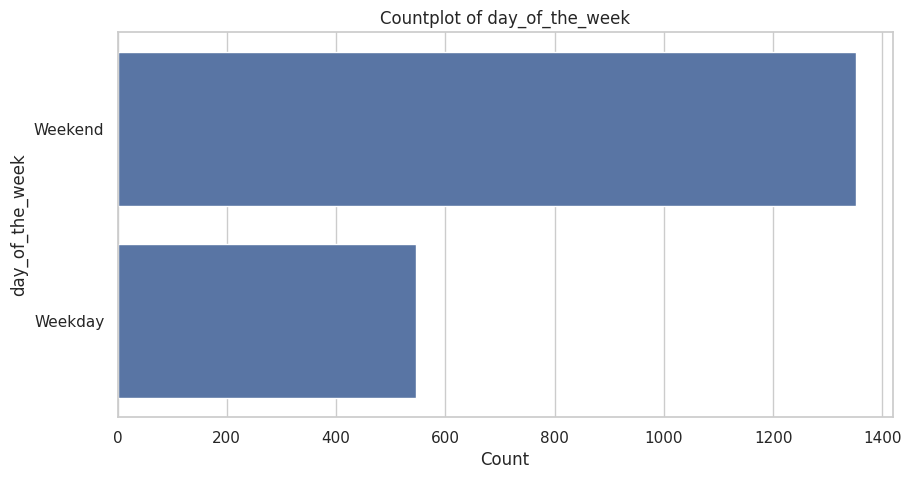

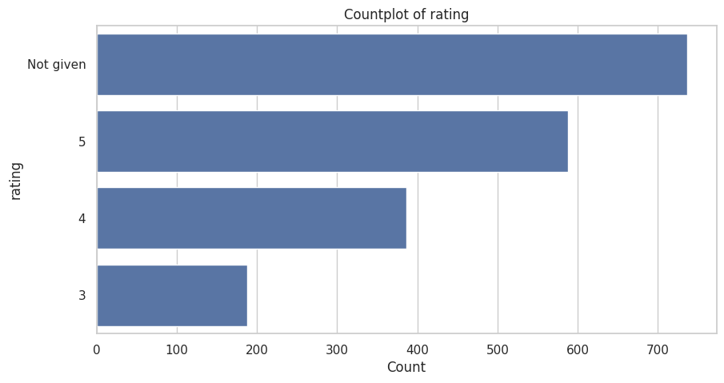

```python
categorical_columns = ['restaurant_name', 'cuisine_type', 'day_of_the_week', 'rating']
for column in categorical_columns:
    plt.figure(figsize=(10, 5))
    sns.countplot(y=df[column], order=df[column].value_counts().index)
    plt.title(f'Countplot of {column}')
    plt.xlabel('Count')
    plt.ylabel(column)
    plt.show()
```

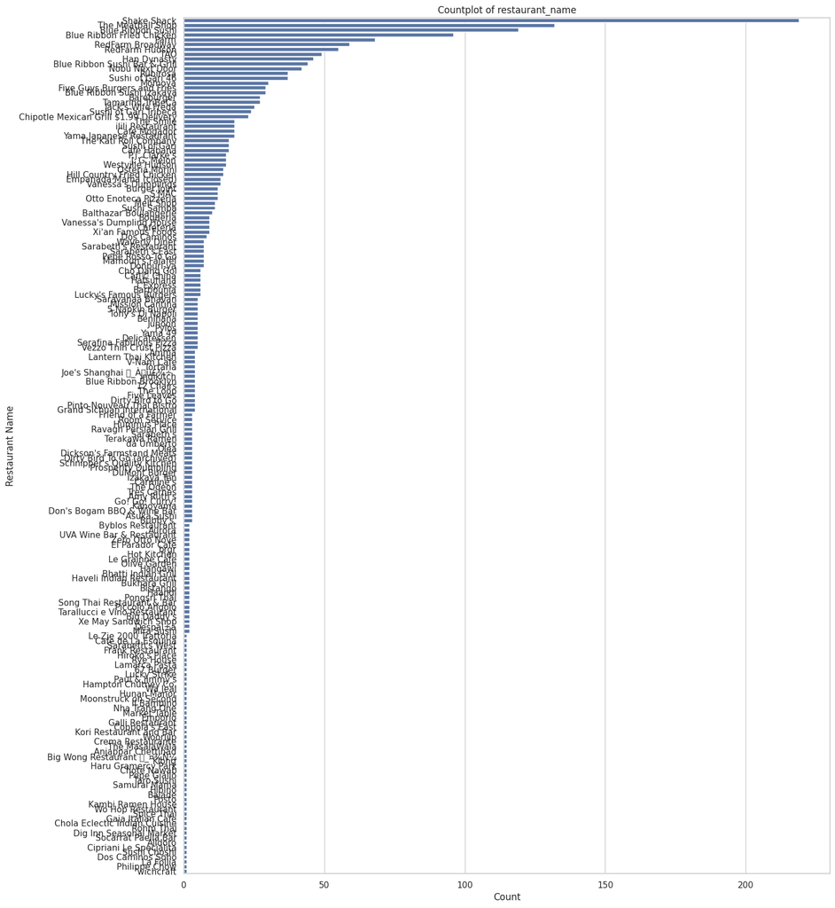

```python
# Improved countplot for 'restaurant_name'
plt.figure(figsize=(15, 20))  # Increase figure size for better readability
sns.countplot(y=df['restaurant_name'], order=df['restaurant_name'].value_counts().index)
plt.title('Countplot of restaurant_name')
plt.xlabel('Count')
plt.ylabel('Restaurant Name')
plt.show()
```

[figure not shown]

```python
# Improved countplot for 'restaurant_name' with margin between bars
plt.figure(figsize=(15, 20))  # Increase figure size for better readability
sns.countplot(y=df['restaurant_name'], order=df['restaurant_name'].value_counts().index, palette="viridis", dodge=False)
plt.title('Countplot of restaurant_name')
plt.xlabel('Count')
plt.ylabel('Restaurant Name')

# Adjust the bar width and add some padding between the bars
for patch in plt.gca().patches:
    current_width = patch.get_width()
    diff = current_width * 0.1  # 10% padding
    patch.set_width(current_width - diff)
    patch.set_x(patch.get_x() + diff / 2)

plt.show()
```

### Observations and insights from Countplot

#### Countplot of Cuisine Type:

- Observation: American cuisine is the most popular, followed by Japanese, Italian, and Chinese cuisines. Vietnamese cuisine has the fewest orders.
- Insight: The high demand for American and Japanese cuisines suggests a strong customer preference. Restaurants offering these cuisines might benefit from increased visibility and promotions. Conversely, promoting lesser-ordered cuisines like Vietnamese could diversify the customer base.

#### Countplot of Day of the Week:

- Observation: Orders are significantly higher on weekends compared to weekdays.
- Insight: The increased order volume on weekends indicates peak business times. Resource allocation, such as staffing and delivery logistics, should be optimized to handle higher demand on weekends.

#### Countplot of Restaurant Name:

- Observation: Shake Shack is the most frequently ordered from restaurant, followed by The Meatball Shop and Blue Ribbon Sushi.
- Insight: Popular restaurants like Shake Shack and The Meatball Shop could be leveraged for cross-promotional activities or featured deals. Lesser-ordered restaurants might need marketing boosts or menu adjustments to increase their order volumes.

#### Countplot of Rating:

- Observation: A significant number of ratings are "Not given" as seen earlier. Among given ratings, 5 is the most common, followed by 4 and then 3.
- Insight: The high number of "Not given" ratings suggests an area for improvement in customer feedback collection. Encouraging customers to rate their orders could provide more actionable insights. The generally high ratings (4 and 5) indicate overall customer satisfaction, but the lower ratings (3) should be investigated for potential service improvements.

### **Question 7**: Which are the top 5 restaurants in terms of the number of orders received?

```python
top_5_restaurants = df['restaurant_name'].value_counts().head(5)

print("Top 5 restaurants in terms of number of orders received:")
print(top_5_restaurants)
```

```
Top 5 restaurants in terms of number of orders received:
restaurant_name
Shake Shack                  219
The Meatball Shop            132
Blue Ribbon Sushi            119
Blue Ribbon Fried Chicken     96
Parm                          68
Name: count, dtype: int64
```

#### Observations:

- Shake Shack is the clear leader in terms of order volume, indicating high customer preference.
- The Meatball Shop and Blue Ribbon Sushi also have a strong presence, suggesting consistent popularity.
- Marketing and promotional efforts could be targeted towards these top restaurants to leverage their popularity and drive further sales.

### **Question 8**: Which is the most popular cuisine on weekends?

```python
# Filter the data for weekend orders
weekend_orders = df[df['day_of_the_week'] == 'Weekend']

# Find the most popular cuisine on weekends
most_popular_cuisine_weekends = weekend_orders['cuisine_type'].value_counts().idxmax()

print(f'The most popular cuisine on weekends is: {most_popular_cuisine_weekends}')
```

```
The most popular cuisine on weekends is: American
```

#### Observations:

- Most Popular Cuisine on Weekends: The most popular cuisine on weekends is American.
- The preference for American cuisine on weekends suggests a strong demand for familiar, comfort food during leisure time. This insight can guide weekend promotional strategies and menu highlights to cater to this preference.

### **Question 9**: What percentage of the orders cost more than 20 dollars?

```python
# Calculate the number of orders that cost more than 20 dollars
orders_above_20 = df[df['cost_of_the_order'] > 20].shape[0]

# Calculate the total number of orders
total_orders = df.shape[0]

# Calculate the percentage of orders that cost more than 20 dollars
percentage_above_20 = (orders_above_20 / total_orders) * 100

print(f'The percentage of orders that cost more than 20 dollars is: {percentage_above_20:.2f}%')
```

```
The percentage of orders that cost more than 20 dollars is: 29.24%
```

#### Observations:

- Approximately 29.24% of the orders have a cost greater than $20.
- A significant portion of the orders are relatively high-value, indicating that many customers are willing to spend more than $20 per order. This insight can be useful for targeting premium promotions and offers to these customers.

### **Question 10**: What is the mean order delivery time?

```python
# Calculate the mean order delivery time
mean_delivery_time = df['delivery_time'].mean()

print(f'The mean order delivery time is: {mean_delivery_time:.2f} minutes')
```

```
The mean order delivery time is: 24.16 minutes
```

#### Observations:

- The delivery process is relatively efficient, with an average delivery time under 25 minutes.
- This information can help the company maintain or further optimize delivery performance to ensure customer satisfaction.

### **Question 11:** The company has decided to give 20% discount vouchers to the top 3 most frequent customers. Find the IDs of these customers and the number of orders they placed

```python
# Find the top 3 most frequent customers
top_3_customers = df['customer_id'].value_counts().head(3)

print("Top 3 most frequent customers and the number of orders they placed:")
print(top_3_customers)
```

```
Top 3 most frequent customers and the number of orders they placed:
customer_id
52832    13
47440    10
83287     9
Name: count, dtype: int64
```

#### Observations:

- The most frequent customer has placed 13 orders.
- The second most frequent customer has placed 10 orders.
- The third most frequent customer has placed 9 orders.

### **Question 12**: Perform a multivariate analysis to explore relationships between the important variables in the dataset. (It is a good idea to explore relations between numerical variables as well as relations between numerical and categorical variables)

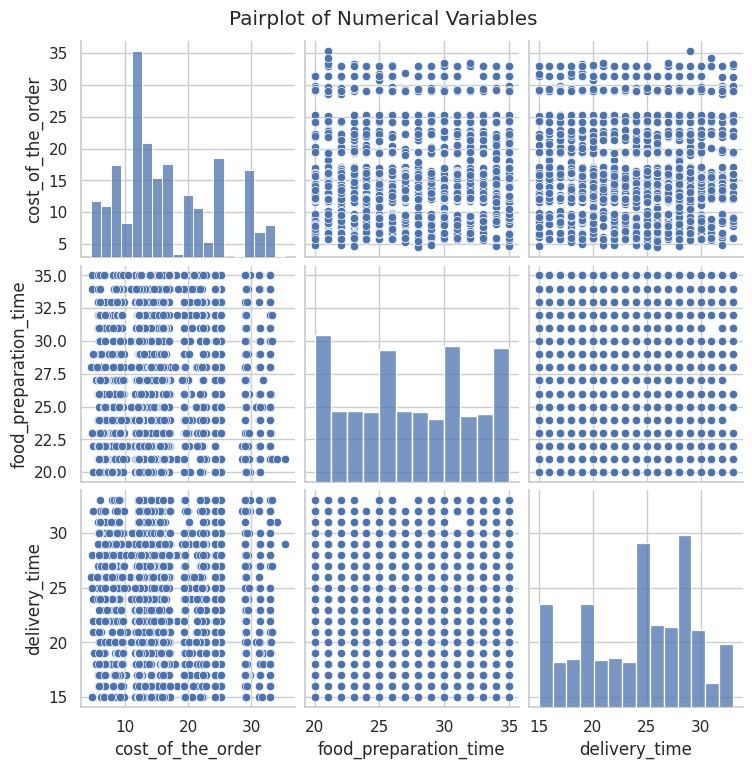

```python
# Set the style of the visualizations
sns.set(style="whitegrid")

# Pairplot to explore relationships between numerical variables
numerical_columns = ['cost_of_the_order', 'food_preparation_time', 'delivery_time']
sns.pairplot(df[numerical_columns])
plt.suptitle('Pairplot of Numerical Variables', y=1.02)
plt.show()
```

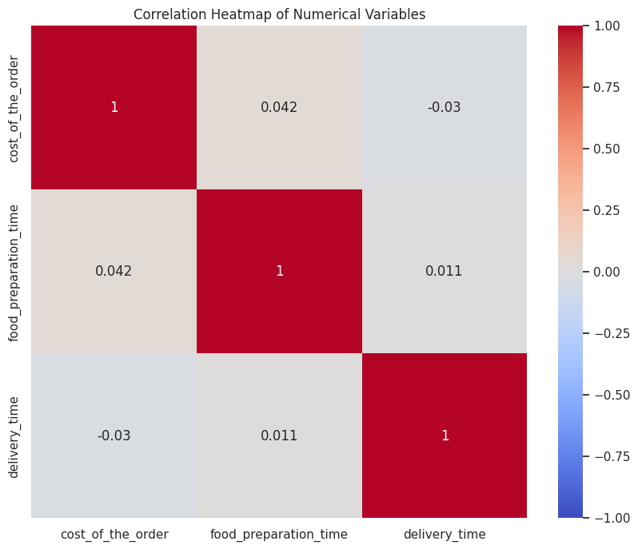

```python
# Heatmap to visualize correlation between numerical variables
plt.figure(figsize=(10, 8))
correlation_matrix = df[numerical_columns].corr()
sns.heatmap(correlation_matrix, annot=True, cmap='coolwarm', vmin=-1, vmax=1)
plt.title('Correlation Heatmap of Numerical Variables')
plt.show()
```

#### Observations from the Pairplot

- Distribution Patterns: The histograms along the diagonal show the distribution of each numerical variable individually.
- Scatter Plots: The scatter plots indicate no clear linear relationship between the pairs of numerical variables, supporting the observation from the correlation heatmap (shown after pairplot) that these variables are mostly independent of each other.

#### Observations from the Correlation Heatmap

- Weak Correlations: The correlations between the numerical variables (cost of the order, food preparation time, and delivery time) are very weak.
- Independence: The variables do not show significant relationships with each other, suggesting that factors such as cost, preparation time, and delivery time are mostly independent.

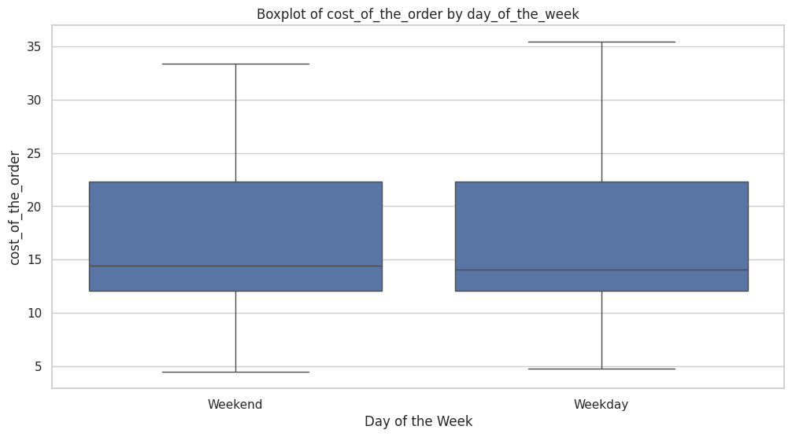

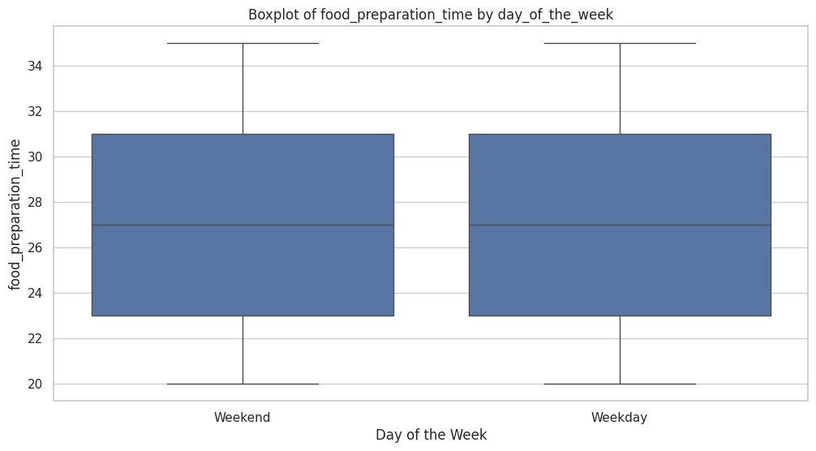

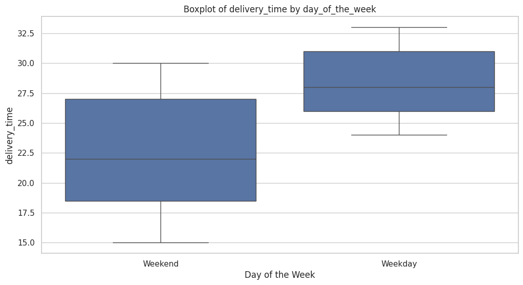

```python
# Boxplots to explore relationships between 'day_of_the_week' and numerical variables
for num_col in numerical_columns:
    plt.figure(figsize=(12, 6))
    sns.boxplot(x='day_of_the_week', y=num_col, data=df)
    plt.title(f'Boxplot of {num_col} by day_of_the_week')
    plt.xlabel('Day of the Week')
    plt.ylabel(num_col)
    plt.show()
```

#### Overall Observations from previous three Box Plots:

- Cost of the Order by Day of the Week:
- The cost of orders tends to be similar on both weekdays and weekends.
- The median cost is slightly higher during weekends compared to weekdays.
- The spread (interquartile range) of the order cost is similar for both weekdays and weekends.

*Food Preparation Time by Day of the Week:

*The food preparation time is consistent across both weekdays and weekends.*The median preparation time is the same for both periods. *There is no significant difference in the range or variability of preparation times between weekdays and weekends.

- Delivery Time by Day of the Week:

*Delivery time is generally longer on weekdays compared to weekends.*The median delivery time is higher on weekdays. *There is greater variability in delivery times during weekends, with some orders taking significantly longer than others.

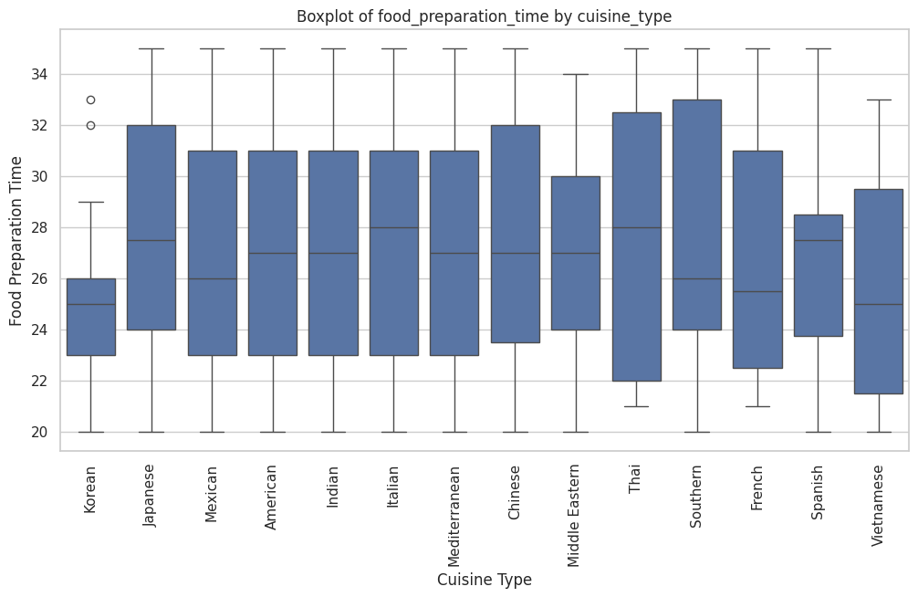

```python
# boxplot for 'food_preparation_time' by 'cuisine_type' with rotated x-axis labels
plt.figure(figsize=(12, 6))
sns.boxplot(x='cuisine_type', y='food_preparation_time', data=df)
plt.title('Boxplot of food_preparation_time by cuisine_type')
plt.xlabel('Cuisine Type')
plt.ylabel('Food Preparation Time')
plt.xticks(rotation=90)  # Rotate x-axis labels
plt.show()
```

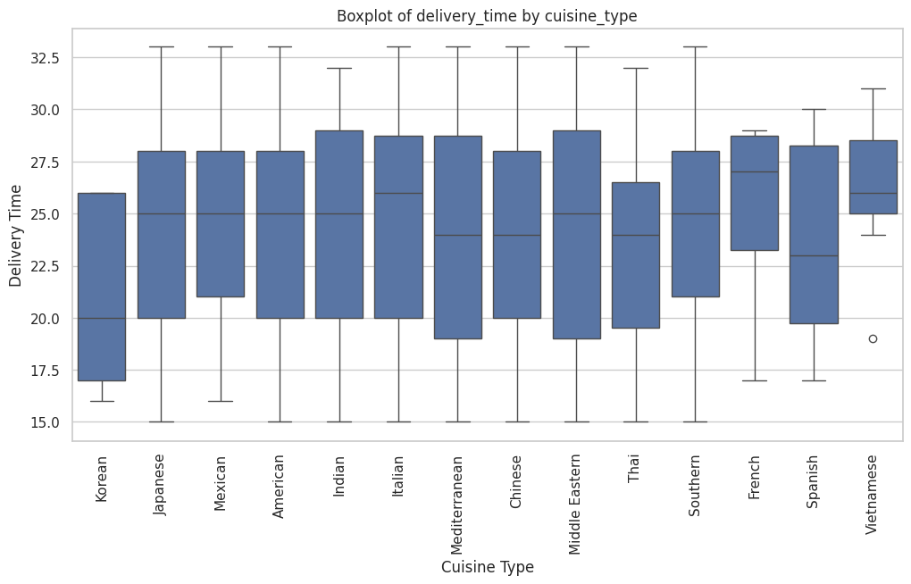

```python
# boxplot for 'delivery_time' by 'cuisine_type' with rotated x-axis labels
plt.figure(figsize=(12, 6))
sns.boxplot(x='cuisine_type', y='delivery_time', data=df)
plt.title('Boxplot of delivery_time by cuisine_type')
plt.xlabel('Cuisine Type')
plt.ylabel('Delivery Time')
plt.xticks(rotation=90)  # Rotate x-axis labels
plt.show()
```

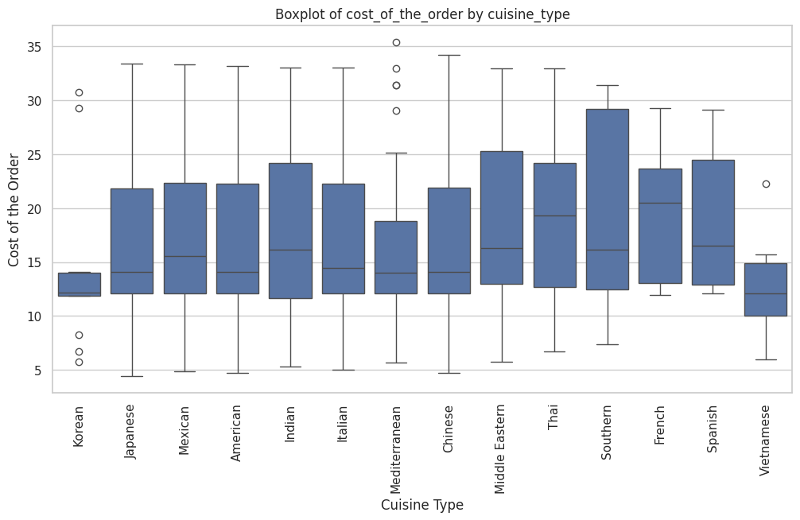

```python
#  boxplot for 'cost_of_the_order' by 'cuisine_type' with rotated x-axis labels
plt.figure(figsize=(12, 6))
sns.boxplot(x='cuisine_type', y='cost_of_the_order', data=df)
plt.title('Boxplot of cost_of_the_order by cuisine_type')
plt.xlabel('Cuisine Type')
plt.ylabel('Cost of the Order')
plt.xticks(rotation=90)  # Rotate x-axis labels
plt.show()
```

### **Question 13:** The company wants to provide a promotional offer in the advertisement of the restaurants. The condition to get the offer is that the restaurants must have a rating count of more than 50 and the average rating should be greater than 4. Find the restaurants fulfilling the criteria to get the promotional offer

```python
# Filter out rows where rating is 'Not given'
df_ratings = df[df['rating'] != 'Not given']

# Convert the rating column to numeric
df_ratings['rating'] = pd.to_numeric(df_ratings['rating'])

# Group by restaurant name and calculate the count and mean of ratings
restaurant_ratings = df_ratings.groupby('restaurant_name')['rating'].agg(['count', 'mean'])

# Filter restaurants with rating count > 50 and average rating > 4
promotional_restaurants = restaurant_ratings[(restaurant_ratings['count'] > 50) & (restaurant_ratings['mean'] > 4)]

print("Restaurants eligible for promotional offer:")
print(promotional_restaurants)
```

```
Restaurants eligible for promotional offer:
                           count      mean
restaurant_name
Blue Ribbon Fried Chicken     64  4.328125
Blue Ribbon Sushi             73  4.219178
Shake Shack                  133  4.278195
The Meatball Shop             84  4.511905
```

#### Observations:

- Blue Ribbon Fried Chicken: This restaurant has received 64 ratings with an average rating of 4.33.
- Blue Ribbon Sushi: This restaurant has received 73 ratings with an average rating of 4.22.
- Shake Shack: This restaurant has received 133 ratings with an average rating of 4.28.
- The Meatball Shop: This restaurant has received 84 ratings with an average rating of 4.51.

### **Question 14:** The company charges the restaurant 25% on the orders having cost greater than 20 dollars and 15% on the orders having cost greater than 5 dollars. Find the net revenue generated by the company across all orders

```python
# Define the revenue calculation function
def calculate_revenue(cost):
    if cost > 20:
        return cost * 0.25
    elif cost > 5:
        return cost * 0.15
    else:
        return 0

# Apply the revenue calculation function to the 'cost_of_the_order' column
df['revenue'] = df['cost_of_the_order'].apply(calculate_revenue)

# Calculate the total revenue
total_revenue = df['revenue'].sum()

print(f'The net revenue generated by the company across all orders is: ${total_revenue:.2f}')
```

```
The net revenue generated by the company across all orders is: $6166.30
```

#### Observations:

- Based on the given fee structure, the total net revenue generated by the company from all orders amounts to $6166.30.
- The significant amount of total revenue indicates a substantial number of orders fall within the chargeable ranges (above $5), with a notable proportion exceeding $20 to generate higher fees

### **Question 15:** The company wants to analyze the total time required to deliver the food. What percentage of orders take more than 60 minutes to get delivered from the time the order is placed? (The food has to be prepared and then delivered)

```python
# Calculate the total time required to deliver the food
df['total_delivery_time'] = df['food_preparation_time'] + df['delivery_time']

# Calculate the number of orders that take more than 60 minutes
orders_above_60 = df[df['total_delivery_time'] > 60].shape[0]

# Calculate the total number of orders
total_orders = df.shape[0]

# Calculate the percentage of orders that take more than 60 minutes
percentage_above_60 = (orders_above_60 / total_orders) * 100

print(f'The percentage of orders that take more than 60 minutes to get delivered is: {percentage_above_60:.2f}%')
```

```
The percentage of orders that take more than 60 minutes to get delivered is: 10.54%
```

### **Question 16:** The company wants to analyze the delivery time of the orders on weekdays and weekends. How does the mean delivery time vary during weekdays and weekends?

```python
# Calculate the mean delivery time for weekdays and weekends
mean_delivery_time_weekday = df[df['day_of_the_week'] == 'Weekday']['delivery_time'].mean()
mean_delivery_time_weekend = df[df['day_of_the_week'] == 'Weekend']['delivery_time'].mean()

print(f'The mean delivery time on weekdays is: {mean_delivery_time_weekday:.2f} minutes')
print(f'The mean delivery time on weekends is: {mean_delivery_time_weekend:.2f} minutes')
```

```
The mean delivery time on weekdays is: 28.34 minutes
The mean delivery time on weekends is: 22.47 minutes
```

#### Observations:

- The mean delivery time on weekdays is: 28.34 minutes
- The mean delivery time on weekends is: 22.47 minutes

### Conclusion and Recommendations

### **Question 17:** What are your conclusions from the analysis? What recommendations would you like to share to help improve the business? (You can use cuisine type and feedback ratings to drive your business recommendations)

### Conclusions:

Cuisine Popularity: American cuisine is the most popular, especially on weekends. Other popular cuisines include Japanese, Italian, and Chinese.

- Order Costs: Most orders are within the range of $10 to $20, with a significant portion exceeding $20, contributing to higher revenue.
- Preparation and Delivery Times: Food preparation times generally range between 20 to 35 minutes. The mean delivery time on weekdays is 28.34 minutes, while on weekends, it is 22.47 minutes. This indicates that delivery is more efficient during weekends.
- Revenue Generation: The company generates a substantial amount of revenue ($6166.30) through its tiered fee structure on orders. A considerable percentage of orders (29.24%) cost more than $20, indicating a healthy revenue stream from high-value orders.
- Customer Engagement: The top 3 most frequent customers placed 13, 10, and 9 orders, respectively, showing consistent engagement from a loyal customer base.
- Restaurant Ratings: Restaurants like Blue Ribbon Fried Chicken, Blue Ribbon Sushi, Shake Shack, and The Meatball Shop meet the criteria for promotional offers due to their high ratings and substantial rating counts.

### Recommendations:

- Focus on Popular Cuisines: Given the popularity of American, Japanese, Italian, and Chinese cuisines, consider partnering with more restaurants offering these types of food to meet customer demand.
- Optimize Order Processing: To enhance customer satisfaction, efforts should be made to optimize food preparation and delivery processes, particularly focusing on weekends when order volumes are higher and delivery is more efficient.
- Targeted Promotions: Utilize feedback ratings to identify high-performing restaurants for promotional offers. Encourage these restaurants to maintain high standards to qualify for future promotions, thus driving overall service quality.
- Loyalty Programs: Implement loyalty programs to reward frequent customers. This can help retain top customers and increase their order frequency.
- Improve Rating System: Address the issue of "Not given" ratings by encouraging customers to leave feedback. This will provide more accurate data for assessing restaurant performance and customer satisfaction.
- Revenue Optimization: Review the current fee structure to ensure it remains competitive and profitable. Consider promotional discounts for orders slightly below $20 to encourage higher spending.
- Operational Efficiency: Monitor and analyze the variability in preparation and delivery times across different cuisines and restaurants to identify areas for operational improvements.

```python
# Download the HTML file

!pip install nbconvert

import nbconvert
import os

notebook_filename = '/content/drive/MyDrive/Python course/FDS_Project_Mbaaoum.ipynb'

# Convert the .ipynb file to HTML
os.system(f'jupyter nbconvert --to html "{notebook_filename}"')

# Download the HTML file
html_filename = notebook_filename.replace('.ipynb', '.html')
from google.colab import files
files.download(html_filename)
```